# HW 10

Brandon Keck

2024-12-08

# Section 6.4

## 6.4-1

$$L = \frac{1}{(\sigma\sqrt{2\pi})^n}
e^{-\frac{\sum(x_i-\mu)^2}{2\sigma^2}}$$

$$ln L = ln \frac{1}{(\sigma\sqrt{2\pi})^n} -
\frac{\sum(x_i-\mu)^2}{2\sigma^2}$$

$$\frac{\partial}{\partial \mu}lnL = 0$$

$$2 \frac{\sum(x_i-\mu)}{2\sigma^2}=0$$

$$\sum(x_i-\mu) = 0$$

$$\sum x_i = n\mu$$

$$\hat{\mu} = \frac{\sum x_i}{n}$$

$$\boxed{\hat{\mu}= \bar{x}}$$

## 6.4-2

$$L = \frac{1}{(\sigma\sqrt{2\pi})^n}
e^{-\frac{\sum(x_i-\mu)^2}{2\sigma^2}}$$

$$ln L = ln \frac{1}{(\sigma\sqrt{2\pi})^n} -
\frac{\sum(x_i-\mu)^2}{2\sigma^2}$$

$$ln L = ln1 - \frac{n}{2}ln\sigma^2 - nln\sqrt{2\pi} -
\frac{\sum(x_i-\mu)^2}{2\sigma^2}$$

$$\frac{\partial}{\partial\sigma^2}lnL = 0$$

$$-\frac{n}{2\sigma^2} + \frac{\sum(x_i-\mu)^2}{2\sigma^2} = 0$$

$$\boxed{\hat{\sigma^2}= \frac{\sum(x_i-\mu)^2}{n}}$$

## 6.4-4

$$p(x) = \frac{2+\theta(2-x)}{6}, x =1,2,3$$

$$E(X) = \sum xp(x)$$

$$E(X) = 1 * \frac{2+\theta}{6} + 2 * \frac{2}{6} + 3 * \frac{2-\theta}{6}$$

$$=\frac{6-\theta}{3}$$

$$\frac{6-\theta}{3} = \bar{x}$$

$$\hat{\theta} = 6-3\bar{x}$$

$$\sum x = 3 + 2 + 3 + 1$$

$$=9$$

$$\bar{x}=\frac{9}{4}$$

$$=2.25$$

$$\hat{\theta} = 6 - 3 * 2.25$$

$$\boxed{\approx -1}$$

## 6.4-5

### (a)

$$L = \frac{1}{\theta ^ {2n}} \pi X_i e -\frac{\sum X_i}{\theta}$$

$$lnL = \frac{1}{\theta ^ {2n}} \pi X_i e -\frac{\sum X_i}{\theta}$$

$$ln L = ln1-2nln\theta + \sum lnX_i - \frac{\sum X_i}{\theta}$$

$$\frac{\partial}{\partial \theta}lnL = 0$$

$$-\frac{2n}{\theta} +\frac{\sum X_i}{\theta^2} = 0$$

$$\boxed{\hat{\theta} = \frac{\bar{X}}{2}}$$

### (b)

$$L = \frac{1}{2\theta ^ {3n}} \pi X^2_i e -\frac{\sum X_i}{\theta}$$

$$lnL = ln\frac{1}{2} - 3nln\theta + 2 \sum ln X_i - \frac{\sum
X_i}{\theta}$$

$$\frac{\partial}{\partial \theta}lnL=0$$

$$-\frac{3n}{\theta} + \frac{\sum X_i}{\theta^2} = 0$$

$$\boxed{\hat{\theta}=\frac{\bar{X}}{3}}$$

### (c)

$$L = \frac{1}{2}e^{-\sum|X_i-\theta|}$$

## 6.4-6

$$L = \frac{1}{(\sigma\sqrt{2\pi})^n}
e^{-\frac{\sum(x_i-\mu)^2}{2\sigma^2}}$$

```r
31.5 + 36.9 + 33.8 + 30.1 + 33.9 +  35.2 + 29.6 + 34.4 + 30.5 + 34.2 +  31.6 + 36.7 + 35.8 + 34.5 + 32.7
```

```
## [1] 501.4
```

$\bar{x}=$

```r
501.4/15
```

```
## [1] 33.42667
```

$\hat{\sigma^2}=$

```r
((31.5 - 33.43)^2 + (36.9 - 33.43)^2 + (33.8 -33.43)^2 + (30.1-33.43)^2 + (33.9 - 33.43)^2 + (35.2 - 33.43)^2 + (29.6-33.43)^2 + (34.4-33.43)^2 + (30.5 - 33.43)^2 + (34.2-33.43)^2 + (31.6 - 33.43)^2 + (36.7 - 33.43)^2 + (35.8-33.43)^2 + (34.5-33.43)^2 + (32.7-33.43)^2) / 15
```

```
## [1] 5.097967
```

$\boxed{5.097967}$

## 6.4-7

### (a)

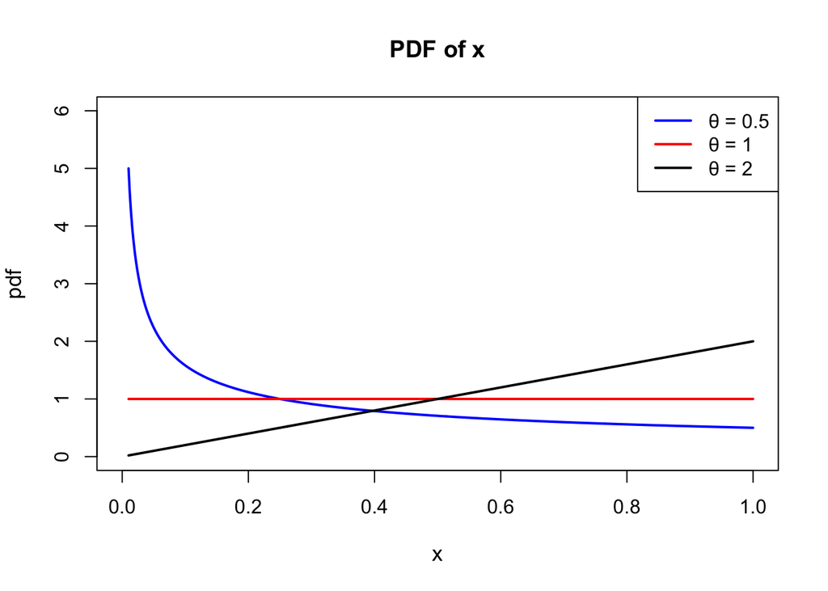

```r
# Define the PDF function
pdf_function <- function(x, theta) {
  theta * x^(theta - 1)
}

# Define the range of x and the theta values
x <- seq(0.01, 1, length.out = 500)
thetas <- c(1/2, 1, 2)
colors <- c("blue", "red", "black")


plot(NULL, xlim = c(0, 1), ylim = c(0, 6), xlab = "x", ylab = "pdf",
     main = "PDF of x", cex.main = 1.2, cex.lab = 1.1)

# Add lines for each theta
for (i in seq_along(thetas)) {
  y <- pdf_function(x, thetas[i])
  lines(x, y, col = colors[i], lwd = 2)
}

# create a legend
legend("topright", legend = paste("θ =", thetas), col = colors, lty = 1, lwd = 2)
```

### (b)

$$L = \theta^n \pi x^{(\theta-1)}$$

$$lnL= ln\theta^n \pi x^{(\theta-1)}$$

$$=nln\theta+(\theta-1)\sum lnx$$

$$\frac{\partial}{\partial\theta}lnL=0$$

$$\frac{n}{\theta} + \sum lnx = 0$$

$$\hat{\theta} = \frac{-n}{\sum lnx}$$

$$\boxed{\hat{\theta}=\frac{-n}{ln(\pi x)}}$$

### (c)

$$L = \theta^n \pi x^{(\theta-1)}$$

$$MLE \ of \ \theta \ is \ \frac{-n}{ln(\pi x)}$$

n = 10

dataset (i)

```r
# Dataset (i)
data_i <- c(0.0256, 0.3051, 0.0278, 0.8971, 0.0739, 0.3191, 0.7379, 0.3671, 0.9763, 0.0102)

# Calculate MLE1 and MOM1
n <- length(data_i)
mean_x <- mean(data_i)
sum_log_x <- sum(log(data_i))



theta_mle_i <- -n / sum_log_x
theta_mom_i <- mean_x / (1 - mean_x)

theta_mle_i
```

```
## [1] 0.5492604
```

```r
theta_mom_i
```

```
## [1] 0.5974696
```

$\boxed{\theta_{MLE1}=0.5492604}$ $\boxed{\theta_{MOM1}=0.5974696}$

dataset (ii)

```r
# Dataset (ii)
data_ii <- c(0.9960, 0.3125, 0.4374, 0.7464, 0.8278, 0.9518, 0.9924, 0.7112, 0.2228, 0.8609)

# Calculate MLE2 and MOM2
mean_x <- mean(data_ii)
sum_log_x <- sum(log(data_ii))

theta_mle_ii <- -n / sum_log_x
theta_mom_ii <- mean_x / (1 - mean_x)

theta_mle_ii
```

```
## [1] 2.210124
```

```r
theta_mom_ii
```

```
## [1] 2.400435
```

$\boxed{\theta_{MLE2}=2.210124}$ $\boxed{\theta_{MOM2}=2.400435}$

dataset (iii)

```r
# Dataset (iii)
data_iii <- c(0.4698, 0.3675, 0.5991, 0.9513, 0.6049, 0.9917, 0.1551, 0.0710, 0.2110, 0.2154)

# Calculate MLE3 and MOM3
mean_x <- mean(data_iii)
sum_log_x <- sum(log(data_iii))

theta_mle_iii <- -n / sum_log_x
theta_mom_iii <- mean_x / (1 - mean_x)

theta_mle_iii
```

```
## [1] 0.9588026
```

```r
theta_mom_iii
```

```
## [1] 0.8645585
```

$\boxed{\theta_{MLE3}=0.9588026}$ $\boxed{\theta_{MOM3}=0.8645585}$

## 6.4-10

### (a)

$$geometric \ distribution \ p(x) = (1-p)^{x-1}, \ x=0,1,2,....$$

$$The \ mean \ of X \ is \frac{1}{p}$$

We can equate $\frac{1}{p} = \bar{x}$ in order to obtain the estimator of p by using the method of moments

$$\frac{1}{p} = \bar{x}$$

$$\hat{p} = \frac{1}{\bar{x}}$$

$$= \boxed{\frac{n}{\sum x}}$$

### (b)

It is reasonably intuitive because using the method of moments as an estimator of (p) highlights the direct relationship between the probability of success (p) and the expected number of trials (E(X)) in the geometric distribution. Since $(E(X) = \frac{1}{p}$, the method-of-moments approach leverages the sample mean $(\bar{X})$ to estimate this relationship, ensuring the estimate for (p) reflects how frequently successes occur in the observed data. A higher sample mean $(\bar{X})$ corresponds to a lower probability of success (p), and vice versa, making the estimate both intuitive and aligned with the distribution’s properties.

### (c)

```r
# Data
data <- c(3, 34, 7, 4, 19, 2, 1, 19, 43, 2, 22, 4, 19, 11, 7, 1, 2, 21, 15, 16)

sum(data)
```

```
## [1] 252
```

```r
# Calculate the sample mean
mean_x <- mean(data)

# Calculate the method of moments estimate for p
p_mom <- 1 / mean_x

p_mom
```

```
## [1] 0.07936508
```

$\boxed{0.07936508}$

## 6.4-12

### (a)

$$p(y) = \binom{n}{y}p^y (1-p)^{n-y}$$

$$E(Y)=np$$

$$E(\sum X) = np$$

$$E(n \bar{X})=np$$

$$\boxed{E(\bar{X})=p}$$

### (b)

$$p(y) = \binom{n}{y}p^y (1-p)^{n-y}$$

$$V(Y) = np(1-p)$$

$$V(\sum X) = np(1-p)$$

$$V(n \bar{X}) = np(1-p)$$

$$n^2V(\bar{X})=np(1-p)$$

$$\boxed{V(\bar{X}) = \frac{p(1-p)}{n}}$$

### (c)

$$p(y) = \binom{n}{y}p^y (1-p)^{n-y}$$

$$V(\bar{X}) = \frac{p(1-p)}{n}$$

$$E[\bar{X}(1-\bar{X}) = E[\bar{X}-\bar{X^2}]$$

$$= E(\bar{X})-E(\bar{X^2})$$

$$= E(\bar{X})-V(\bar{X})-E^2(\bar{X})$$

$$= p - \frac{p(1-p)}{n}-p^2$$

$$= \frac{np-p(1-p)-np^2}{n}$$

$$= \frac{np(1-p)-p(1-p)}{n}$$

$$\boxed{= \frac{(n-1)p(1-p)}{n}}$$

### (d)

$$E[c\bar{X}(1-\bar{X})] = p(1-p)$$

$$cE[\bar{X}-\bar{X^2}] = p(1-p)$$

$$c[E(\bar{X})-E(\bar{X^2})] = p(1-p)$$

$$c[E(\bar{X})-V(\bar{X})-E^2(\bar{X})] = p(1-p)$$

$$c[p-\frac{p(1-p)}{n}-p^2] = p(1-p)$$

$$c[\frac{np-p(1-p)-np^2}{n}] = p(1-p)$$

$$c[\frac{np(1-p)-p(1-p)}{n}] = p(1-p)$$

$$c[\frac{(n-1)p(1-p)}{n}] = p(1-p)$$

$$\boxed{c = \frac{n}{n-1}}$$

## 6.4-15

$$\bar{x} = \frac{\sum x}{n}$$

```r
6.9 + 7.3 + 6.7 + 6.4 + 6.3 + 5.9 + 7.0 + 7.1 + 6.5 + 7.6 + 7.2 + 7.1 + 6.1 + 7.3 + 7.6 + 7.6 + 6.7 + 6.3 + 5.7 + 6.7 + 7.5 + 5.3 + 5.4 + 7.4 + 6.9
```

```
## [1] 168.5
```

$\bar{x}=$

```r
168.5/25
```

```
## [1] 6.74
```

$var(x) = \frac{\sum x^2}{n}-\bar{x^2}$

```r
(6.9^2) + (7.3^2) + (6.7^2) + (6.4^2) + (6.3^2) + (5.9^2) + (7.0^2) + (7.1^2) + (6.5^2) + (7.6^2) + (7.2^2) + (7.1^2) + (6.1^2) + (7.3^2) + (7.6^2) + (7.6^2) + (6.7^2) + (6.3^2) + (5.7^2) + (6.7^2) + (7.5^2) + (5.3^2) + (5.4^2) + (7.4^2) + (6.9^2)
```

```
## [1] 1146.77
```

var(x)

```r
1146.77 / 25 - (6.74^2)
```

```
## [1] 0.4432
```

$\hat{\theta}=\frac{var(x)}{\bar{x}}$

```r
0.4432 / 6.74
```

```
## [1] 0.06575668
```

$\hat{\alpha}=\frac{\bar{x}}{\hat{\theta}}$

```r
6.74 / 0.06575668
```

```
## [1] 102.4991
```

$\boxed{\hat{\theta} = 0.06575668}$

$\boxed{\hat{\alpha} = 102.4991}$

## 6.4-16

$$\bar{x} = \frac{\sum x}{N}$$

```r
3+0+0+1+1+1+1+3+1+1+2+0+1+3+1+0+1+0+2+1+1+2+3+2+2+4+3+1+1+2
```

```
## [1] 44
```

$\hat{p}=\bar{x}$

```r
44/30
```

```
## [1] 1.466667
```

```r
8 * 1.466667
```

```
## [1] 11.73334
```

$\boxed{11.73334}$

Reasoning: Since the expected number of orange balls is proportional to $N_1$ the sample mean is directly informs this relationship. The method of moments ensures consistency with the data by matching the sample mean to the theoretical mean.

# Section 6.7

## 6.7-4

### (a)

$$f(x_1,x_2,....,x_n) = \theta^n \prod_{i=1}^n x_i^{\theta-1}$$

$$= \theta^n (\prod_{i=1}^n x_i)^{\theta-1}$$

$$\boxed{Y = \prod_{i=1}^n X_i}$$

### (b)

$$L(\theta) = \theta^n (\prod_{i=1}^n x_i)^{\theta-1}$$

$$lnL(\theta) = nln(\theta) + (\theta-1)ln(\prod_{i=1}^n x_i)$$

$$nln(\theta) + (\theta-1) \sum_{i=1}^n ln x_i$$

$$\frac{d}{d\theta} lnL(\theta) = \frac{d}{d\theta}(nln\theta + \theta
\sum_{i=1}^n lnx_i - \sum_{i=1}^n lnx_i)$$

$$= \frac{n}{\theta} + \sum_{i=1}^n lnx_i$$

$$0 = \frac{d}{d\theta}lnL(\theta)$$

$$0 = \frac{n}{\theta} + \sum_{i=1}^n lnx_i$$

$$0 = n + \theta \sum_{i=1}^n lnx_i$$

$$n = - \theta \sum_{i=1}^n lnx_i$$

$$\theta = - \frac{n}{\sum_{i=1}^n lnx_i}$$

$$\boxed{\hat{\theta} = - \frac{n}{ln \prod_{i=1}^n x_i}}$$

### (c)

The maximum likelihood estimator is sufficient for $\theta$ because it is a one-to-one function of Y which is a sufficient statistic for $\theta$ as showny by the factorization theorem.

## 6.7-7

### (a)

$$f(x_1, x_2,...,x_n) = p^{n} \prod_{x=1}^{n}(1-p)^{x_{i}-1}$$

$$= p^{n}(1-p)^{\sum_{i=1}^n x_{i}-n}$$

$$Y=\sum_{i=1}^{n}X_i$$

### (b)

$$E(Y) = E(\sum_{i=1}^{n}X_i)$$

$$= \sum_{i=1}^{n} E(X_i)$$

$$= \sum_{i=1}^{n} E(X)$$

$$=nE(X)$$

$$=n * \frac{1}{p}$$

$$=\frac{n}{p}$$

$$E(\frac{Y}{n}) = \frac{E(X)}{n}$$

$$= n * \frac{p}{n}$$

$$= \frac{1}{p}$$